# White Wines Quality Exploration by Sanjeev Yadav

# Bivariate Analysis

### Talk about some of the relationships you observed in this part of the investigation. How did the feature(s) of interest vary with other features in the dataset?

A very strong correlation was observed in case of alcohol. It had a strong correlation with density and residual sugar. But there was no feature which had a strong enough correlation with quality. It was difficult to assign a higher significance level to a particular feature.

### Did you observe any interesting relationships between the other features (not the main feature(s) of interest)?

The density had some interesting correlation with other features. Excluding the main features, the density had the highest values for correlation co-efficients.

### What was the strongest relationship you found?

The strongest correlation was between density and residual sugar. Correlation coefficient for this pair was 0.83. Density and alcohol also have high correlation of -0.81.

# Multivariate Plots Section

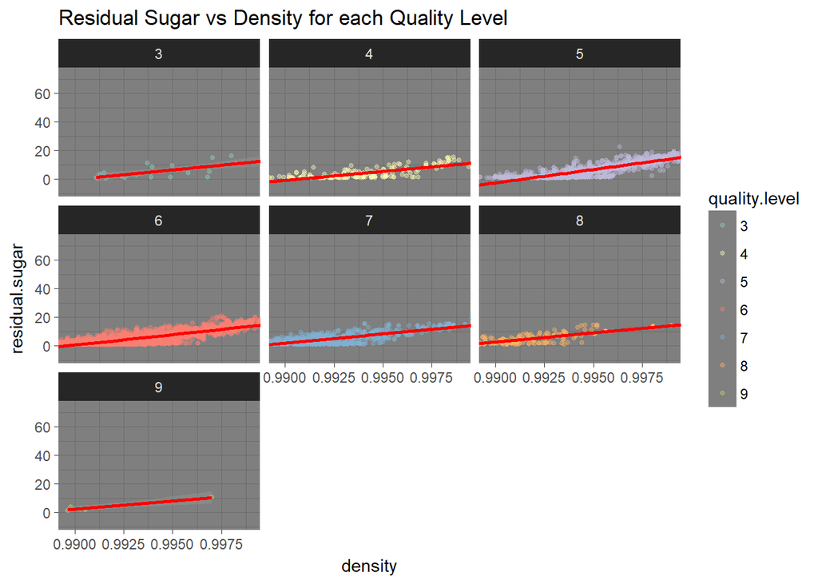

There is positive correlation between residual sugar and density for every quality rating.

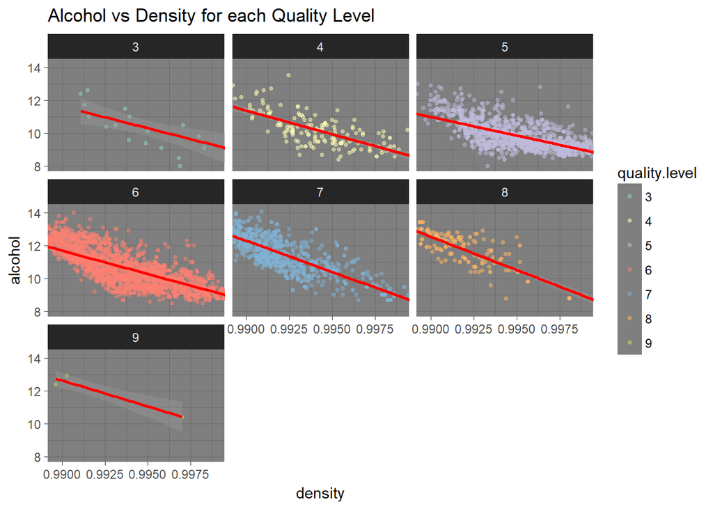

There are very less wines with high quality and they all fall in the top left region of the first quadrant here.

Now lets see the behaviour of quality vs the other features of interest, i.e., alcohol, residual sugar and total acidity.

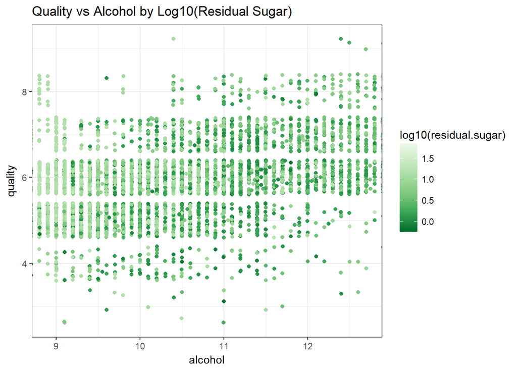

It looks like high quality wines have high residual sugar(the light green points near quality 8). Coloring by residual sugar does not provide a clear separation between high quality and low quality wines.

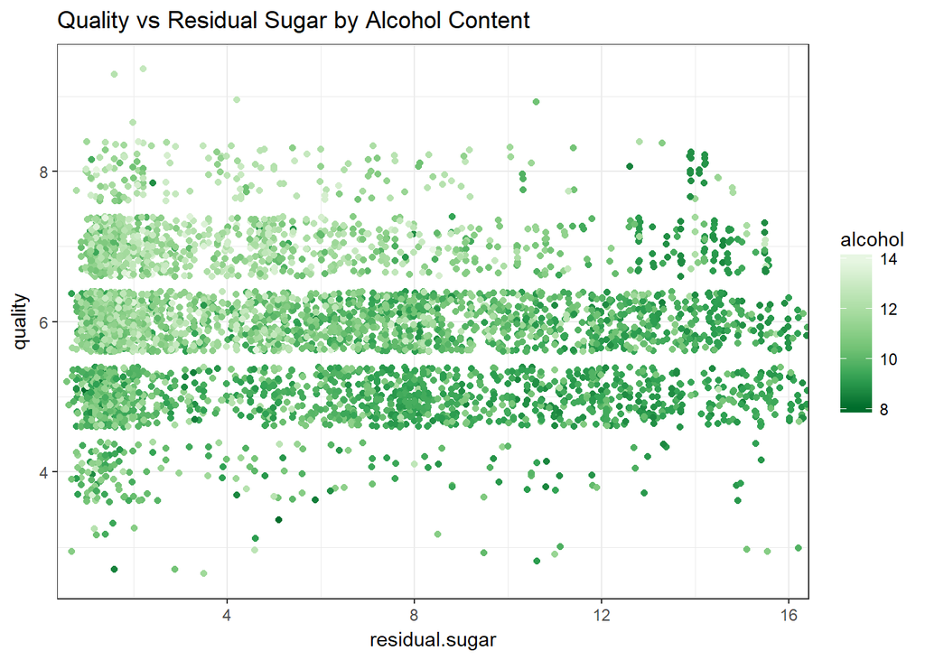

Clearly high quality wines have high alcohol content(in the top left part of graph). Some low alcohol wines are also there but there are very few.

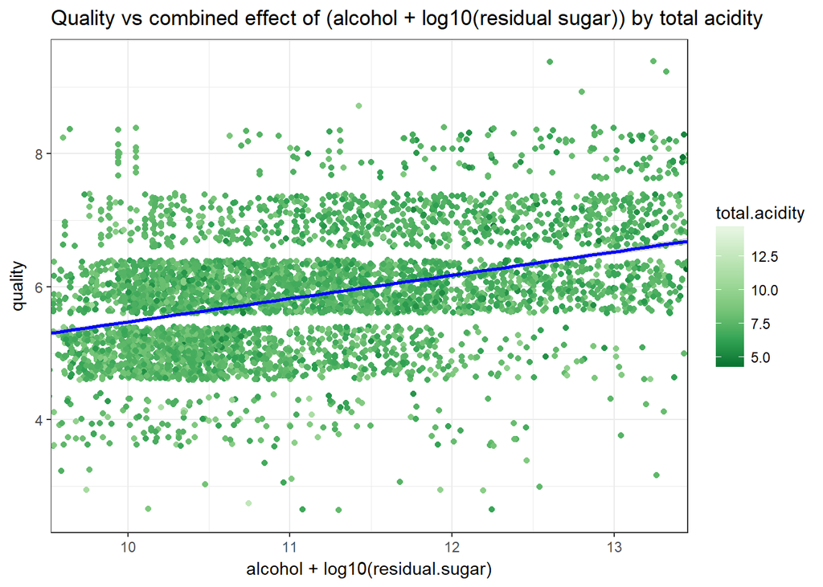

Total acidity does not provide a clear separation between type of wines but this graph is showing a weak positive correlation when combined effect of alcohol and residual sugar is taken into account.

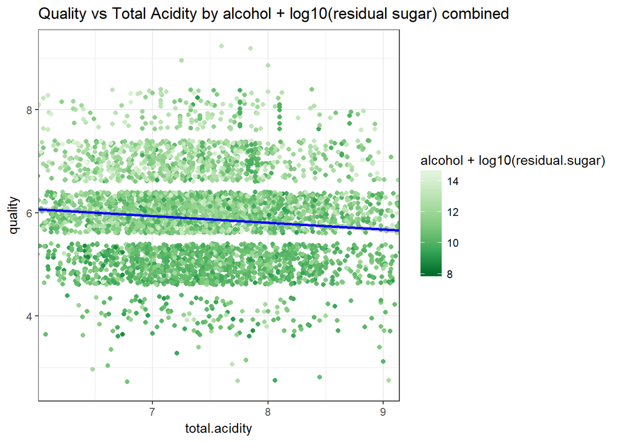

Not a strong relation but quality tends to decrease gradually with acidity content. The same result was obtained in the bivariate plots section.

These plots do not provide a strong idea of how to predict the quality of a wine. Very few relationships exist and they all have a very weak correlation when it comes to predicting quality directly.

```r
m1 <- lm(quality ~ alcohol, data = w)
m2 <- update(m1, ~ . + log10(residual.sugar))
m3 <- update(m2, ~ . + total.acidity)
summary(m3)
```

```
##
## Call:
## lm(formula = quality ~ alcohol + log10(residual.sugar) + total.acidity,
##     data = w)
##
## Residuals:
##     Min      1Q  Median      3Q     Max
## -3.5799 -0.5287 -0.0104  0.4770  3.2541
##
## Coefficients:
##                        Estimate Std. Error t value Pr(>|t|)
## (Intercept)            2.729844   0.154573  17.661  < 2e-16 ***
## alcohol                0.343059   0.009984  34.361  < 2e-16 ***
## log10(residual.sugar)  0.288359   0.030592   9.426  < 2e-16 ***
## total.acidity         -0.086298   0.012768  -6.759 1.55e-11 ***
## ---
## Signif. codes:  0 '***' 0.001 '**' 0.01 '*' 0.05 '.' 0.1 ' ' 1
##
## Residual standard error: 0.7871 on 4894 degrees of freedom
## Multiple R-squared:  0.2106, Adjusted R-squared:  0.2101
## F-statistic: 435.2 on 3 and 4894 DF,  p-value: < 2.2e-16
```

# Multivariate Analysis

### Talk about some of the relationships you observed in this part of the investigation. Were there features that strengthened each other in terms of looking at your feature(s) of interest?

### Were there any interesting or surprising interactions between features?

As seen in bivariate plots section, density has a strong correlation with residual sugar and alcohol. No other feature showed this much strong interaction.

### OPTIONAL: Did you create any models with your dataset? Discuss the strengths and limitations of your model.

# Final Plots and Summary

### Plot One

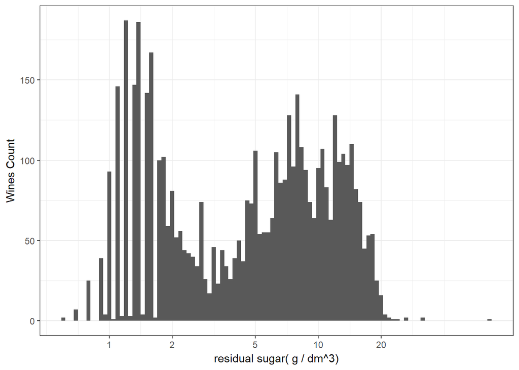

### Description One

The distribution of residual sugar appears bimodal. Maybe wines are categorized on the basis of sweetness of wine. But there is not a clear separation between those categories. Residual sugar contains outliers also.

### Plot Two

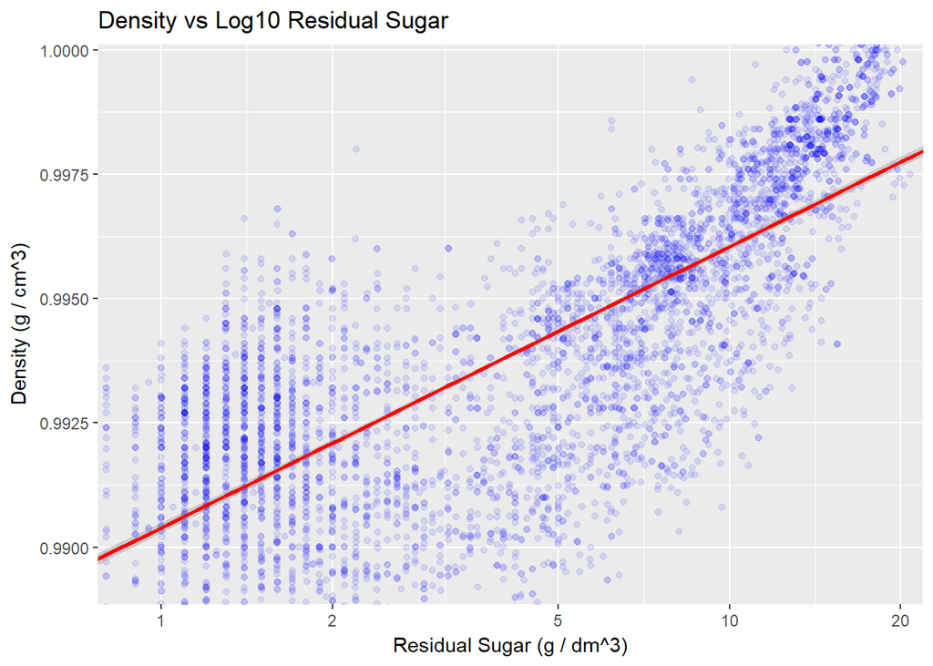

### Description Two

Residual sugar has the strongest relationship with other features. It has almost linear relationship with density with a correlation coefficient of 0.83.

### Plot Three

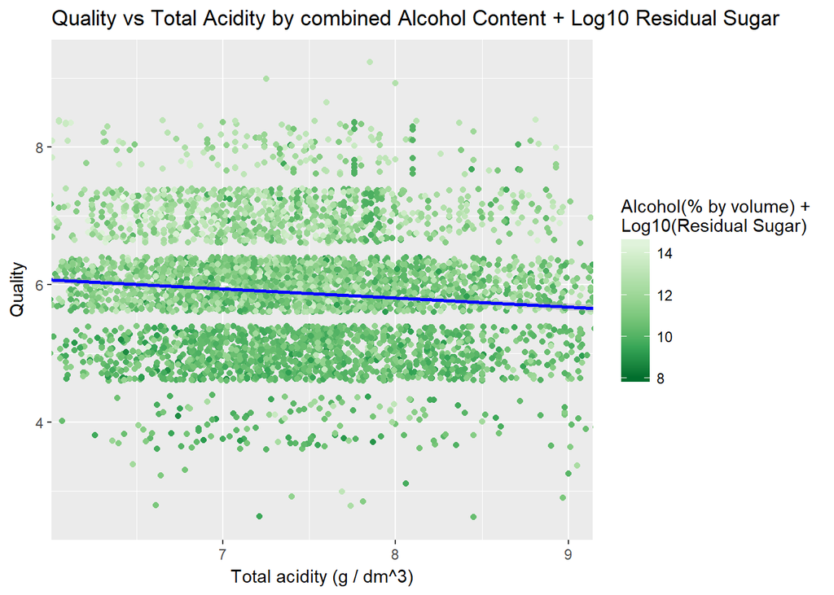

### Description Three

Quality rating has a weak correlation with total acidity. High quality wines have less acidity with high alcohol content and residual sugar value.

```
##
## Call:
## lm(formula = quality ~ total.acidity + log10(residual.sugar) +
##     alcohol, data = w)
##
## Residuals:
##     Min      1Q  Median      3Q     Max
## -3.5799 -0.5287 -0.0104  0.4770  3.2541
##
## Coefficients:
##                        Estimate Std. Error t value Pr(>|t|)
## (Intercept)            2.729844   0.154573  17.661  < 2e-16 ***
## total.acidity         -0.086298   0.012768  -6.759 1.55e-11 ***
## log10(residual.sugar)  0.288359   0.030592   9.426  < 2e-16 ***
## alcohol                0.343059   0.009984  34.361  < 2e-16 ***
## ---
## Signif. codes:  0 '***' 0.001 '**' 0.01 '*' 0.05 '.' 0.1 ' ' 1
##
## Residual standard error: 0.7871 on 4894 degrees of freedom
## Multiple R-squared:  0.2106, Adjusted R-squared:  0.2101
## F-statistic: 435.2 on 3 and 4894 DF,  p-value: < 2.2e-16
```

Linear model also provides a R-squared values of 21.1 %. Only 21% of the variance can be explained by these predictors.

# Reflection

This dataset contains information about chemical properties of 4898 white wines. Exploratory data analysis was carried to study the relationship between features. Going through the internet helped to figure out how these features can be use collectively to explain the quality of wines. Density has a strong correlation with residual sugar and alcohol, but that did not help in predicting the quality of wine. No feature could explain a good amount of variance in quality. Finally the combined features of total acidity, residual sugar and alcohol accounted for only 21% of the variance.

One limitation of this dataset is that the quality rating were more around average rating. Most of the wines have rating of 6 and it was difficult to generalize a linear model to predict the quality.

One addition which can be done in future analysis is the addition of new features which better explain the variance in quality. Including more wines of rating other than 6 will help to generalize a regression model trying to predict the quality of wine.

# References

1. https://www.everwonderwine.com/blog/2017/1/14/is-there-a-relationship-between-a-wines-alcohol-level-and-its-sweetness?format=amp
2. http://winefolly.com/review/understanding-acidity-in-wine/